# DTSA5510

### DTSA 5510 Unsupervised Algorithms in Machine Learning Final Project

**Instructions: Step 1**

**Gather data, determine the method of data collection and provenance of the data (3 points)**

In the earliest phase, select a data source and problem. Feel free to share and discuss your idea on the class discussion board.

AllLife Bank wants to focus on its credit card customer base in the next financial year. They have been advised by their marketing research team, that the penetration in the market can be improved. Based on this input, the Marketing team proposes to run personalised campaigns to target new customers as well as upsell to existing customers. Another insight from the market research was that the customers perceive the support services of the back poorly. Based on this, the Operations team wants to upgrade the service delivery model, to ensure that customers queries are resolved faster. Head of Marketing and Head of Delivery both decide to reach out to the Data Science team for help.

Data Source : https://www.kaggle.com/datasets/eyowakim/credit-card-customer-data

Data Description : Data is of various customers of a bank with their credit limit, the total number of credit cards the customer has, and different channels through which customer has contacted the bank for any queries, different channels include visiting the bank, online and through a call centre.

1. SL_No : Serial Number
2. Customer Key - Customer Idenfification Number
3. Avg_Credit_Limit - Average Credit Card limit for each customer
4. Total_Credit_Cards - Total number of credit cards by customer
5. Total_Visits_Bank - Total number of visits that customer made (yearly) personally to the bank
6. Total_Visits_online - Total number of visits or online logins made by the customer (yearly)
7. Total_calls_made - Total number of calls made by the customer to the bank or its customer service department (yearly)

### Problem Approach

As the Data Science team, the first step would be to understand the available data and define the problem statement. Some potential steps to address the marketing and operations challenges could include:

- Analyzing customer data: By analyzing customer data, the team can identify patterns and trends in customer behavior, such as spending habits, usage of credit card features, and customer demographics. This analysis can help the marketing team to identify new customer segments to target with personalized campaigns, and can also help the operations team to understand where customers are experiencing the most issues.
- Developing predictive models: The team can use machine learning techniques to develop predictive models that can forecast which customers are most likely to respond positively to a particular campaign or to upsell offers. This can help the marketing team to prioritize which customers to target with their campaigns, and can also help the operations team to predict which customers are most likely to have service issues.
- Improving customer support: By analyzing customer support data, the team can identify which types of issues are most commonly reported by customers and develop solutions to address those issues. For example, the team can develop chatbots or other automated systems that can quickly resolve common customer queries, freeing up human support staff to focus on more complex issues.
- Monitoring campaign and support effectiveness: The team can track the effectiveness of marketing campaigns and customer support initiatives over time by analyzing key performance metrics such as customer satisfaction scores, customer retention rates, and credit card usage rates. This analysis can help the marketing and operations teams to continuously improve their strategies and tactics.

**Instructions: Step 3**

**Exploratory Data Analysis (EDA) - Inspect, Visualize, and Clean the Data (26 points)**

Go through the initial data cleaning and EDA and judge whether you need to collect more or different data.

**EDA Procedure Example:**

- Describe the factors or components that make up the dataset (The "factors" here are called "features" in the machine learning term. These factors are often columns in the tabulated data). For each factor, use a box-plot, scatter plot, histogram, etc., to describe the data distribution as appropriate.
- Describe correlations between different factors of the dataset and justify your assumption that they are correlated or not correlated. You may use numeric or qualitative/graphical analysis for this step.
- Determine if any data needs to be transformed. For example, if you're planning on using an SVM method for prediction, you may need to normalize or scale the data if there is a considerable difference in the range of the data.
- Using your hypothesis, indicate if it's likely that you should transform data, such as using a log transform or other transformation of the dataset.
- You should determine if your data has outliers or needs to be cleaned in any way. Are there missing data values for specific factors? How will you handle the data cleaning? Will you discard, interpolate or otherwise substitute data values?
- If you believe that specific factors will be more important than others in your analysis, you should mention which and why. You will use this to confirm your intuitions in your final write-up.

```python
#importing necessary libraries
import pandas as pd
import numpy as np
import seaborn as sns
import matplotlib.pyplot as plt
from scipy.stats import zscore
%matplotlib inline

from sklearn.preprocessing import StandardScaler
from scipy.spatial.distance import cdist
from scipy.spatial.distance import pdist
from sklearn.cluster import KMeans
from sklearn.metrics import silhouette_score
from yellowbrick.cluster import KElbowVisualizer, SilhouetteVisualizer

from scipy.cluster.hierarchy import dendrogram, linkage,cophenet
#from sklearn.metrics import silhouette_score
from sklearn.cluster import AgglomerativeClustering
```

```python
# Reading data from excel file
df=pd.read_excel("Credit Card Customer Data.xlsx")
```

```python
df.head()
```

|  | Sl_No | Customer Key | Avg_Credit_Limit | Total_Credit_Cards | Total_visits_bank | Total_visits_online | Total_calls_made |
| --- | --- | --- | --- | --- | --- | --- | --- |
| 0 | 1 | 87073 | 100000 | 2 | 1 | 1 | 0 |
| 1 | 2 | 38414 | 50000 | 3 | 0 | 10 | 9 |
| 2 | 3 | 17341 | 50000 | 7 | 1 | 3 | 4 |
| 3 | 4 | 40496 | 30000 | 5 | 1 | 1 | 4 |
| 4 | 5 | 47437 | 100000 | 6 | 0 | 12 | 3 |

```python
#dropping the serial no. column
df.drop(['Sl_No','Customer Key'],axis=1,inplace=True)
```

```python
df.info()
```

```
<class 'pandas.core.frame.DataFrame'>
RangeIndex: 660 entries, 0 to 659
Data columns (total 5 columns):
 #   Column               Non-Null Count  Dtype
---  ------               --------------  -----
 0   Avg_Credit_Limit     660 non-null    int64
 1   Total_Credit_Cards   660 non-null    int64
 2   Total_visits_bank    660 non-null    int64
 3   Total_visits_online  660 non-null    int64
 4   Total_calls_made     660 non-null    int64
dtypes: int64(5)
memory usage: 25.9 KB
```

**Observations** : We have 660 rows and 5 columns in the data. All variables are of type integer.

```python
df.describe()
```

|  | Avg_Credit_Limit | Total_Credit_Cards | Total_visits_bank | Total_visits_online | Total_calls_made |
| --- | --- | --- | --- | --- | --- |
| count | 660.000000 | 660.000000 | 660.000000 | 660.000000 | 660.000000 |
| mean | 34574.242424 | 4.706061 | 2.403030 | 2.606061 | 3.583333 |
| std | 37625.487804 | 2.167835 | 1.631813 | 2.935724 | 2.865317 |
| min | 3000.000000 | 1.000000 | 0.000000 | 0.000000 | 0.000000 |
| 25% | 10000.000000 | 3.000000 | 1.000000 | 1.000000 | 1.000000 |
| 50% | 18000.000000 | 5.000000 | 2.000000 | 2.000000 | 3.000000 |
| 75% | 48000.000000 | 6.000000 | 4.000000 | 4.000000 | 5.000000 |
| max | 200000.000000 | 10.000000 | 5.000000 | 15.000000 | 10.000000 |

**Observations**

- Median of Average Credit Limit is 18000
- THe median of Total Credit cards is 5

```python
#Check if there are any null values
df.isna().sum()
```

```
Avg_Credit_Limit       0
Total_Credit_Cards     0
Total_visits_bank      0
Total_visits_online    0
Total_calls_made       0
dtype: int64
```

There are on missing values in data.

#### EDA - Univariate Analysis

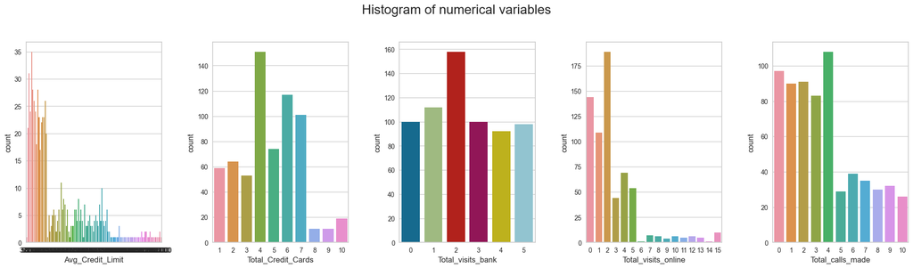

```python
all_col = df.iloc[:].columns.tolist()
fig, axes = plt.subplots(1, 5,  figsize=(20, 6))
fig.suptitle('Histogram of numerical variables', fontsize=20)
counter = 0
for ii in range(5):
    sns.countplot(ax=axes[ii],x=df[all_col[counter]])
    counter = counter+1

fig.tight_layout(pad=2.0)
```

**Observations**

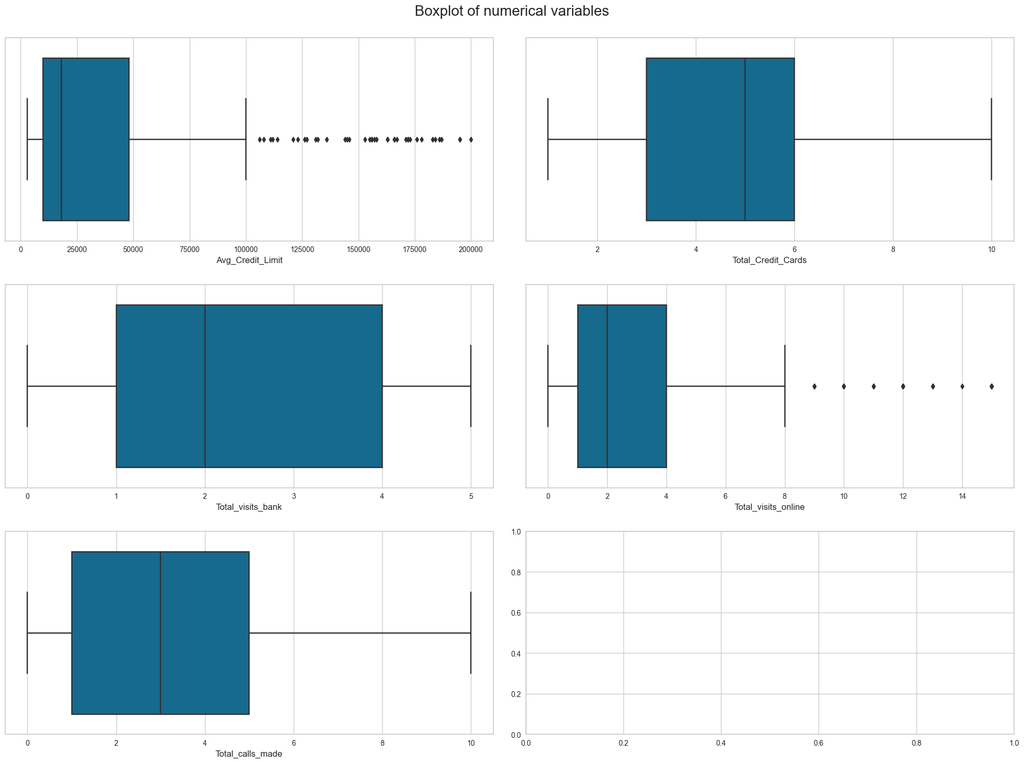

```python
# selecting numerical columns
all_col = df.select_dtypes(include=np.number).columns.tolist()

fig, axes = plt.subplots(3, 2,  figsize=(20, 15))
fig.suptitle('Boxplot of numerical variables', fontsize=20)
counter = 0
for ii in range(3):
    sns.boxplot(ax=axes[ii][0],x=df[all_col[counter]])
    counter = counter+1
    if counter != 5:
        sns.boxplot(ax=axes[ii][1],x=df[all_col[counter]])
        counter = counter+1
    else:
        pass

fig.tight_layout(pad=2.0)
```

#### EDA - Bivariate Analysis

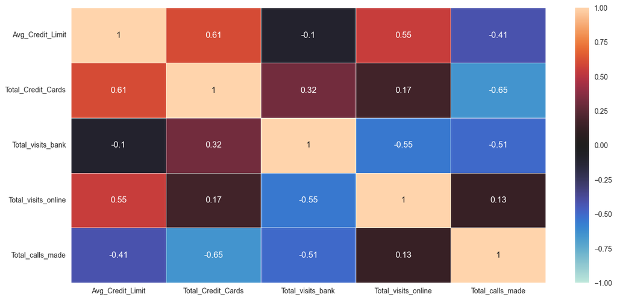

```python
plt.figure(figsize=(15,7))

sns.heatmap(df[all_col].corr(),
            annot=True,
            linewidths=0.5,vmin=-1,vmax=1,
            center=0,
            cbar=True,)

plt.show()
```

##### Pair Plots

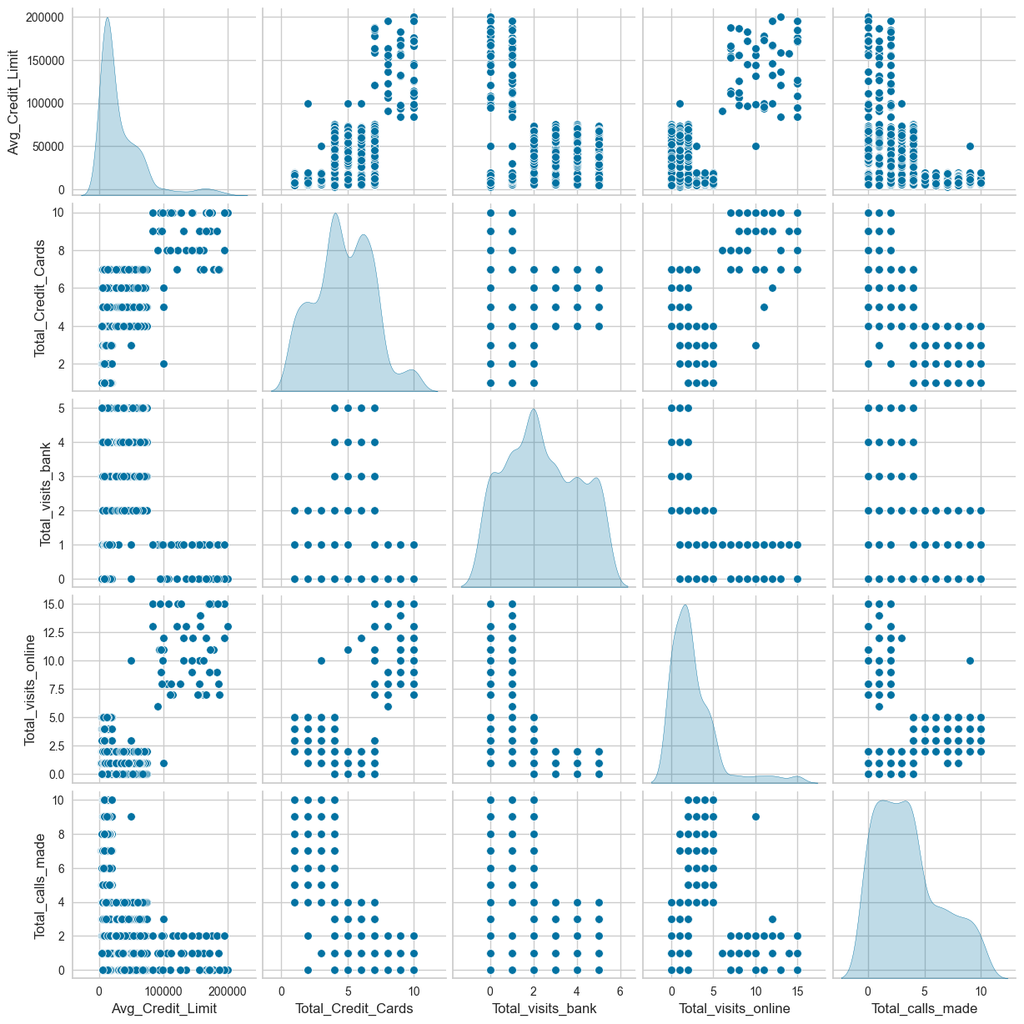

```python
sns.pairplot(df[all_col],diag_kind="kde")
```

**Observations**

**Instructions: Step 4**

**Perform Analysis Using Unsupervised Learning Models of your Choice, Present Discussion, and Conclusions (70 points)**

Model building and training may depend on their data type(s) and task type(s). Depending on your project, you may have one model or more. Generally, it is deemed a higher quality project if you **compare multiple models** and show your understanding of why specific models work better than the other or what limitations or cautions specific models may have. **When using multiple models, at least one of them should be an unsupervised approach.**

For machine learning models, another recommendation is to show enough effort on the hyperparameter optimization.

If your project involves making a web app (not required), you can include the demo.

```python
# Scaling the data set before clustering
scaler=StandardScaler()
subset=df[all_col].copy()
subset_scaled=scaler.fit_transform(subset)
```

```python
#Creating a dataframe from the scaled data above
subset_scaled_df=pd.DataFrame(subset_scaled,columns=subset.columns)
subset_scaled_df.head()
```

|  | Avg_Credit_Limit | Total_Credit_Cards | Total_visits_bank | Total_visits_online | Total_calls_made |
| --- | --- | --- | --- | --- | --- |
| 0 | 1.740187 | -1.249225 | -0.860451 | -0.547490 | -1.251537 |
| 1 | 0.410293 | -0.787585 | -1.473731 | 2.520519 | 1.891859 |
| 2 | 0.410293 | 1.058973 | -0.860451 | 0.134290 | 0.145528 |
| 3 | -0.121665 | 0.135694 | -0.860451 | -0.547490 | 0.145528 |
| 4 | 1.740187 | 0.597334 | -1.473731 | 3.202298 | -0.203739 |

#### Using K-Means Clustering

K-Means clustering is an unsupervised learning algorithm that partitions data points into K clusters based on similarity. The algorithm works by iteratively assigning data points to their nearest cluster centroid and then recalculating the centroids based on the new assignments.

We will also use elbow method technique to determine optimal number of clusters to use in K-Means clustering. In involves plotting the within-cluster sum of squares for different values of K and selecting the value of K where the decrease of sum of the squares began to level off.

We will use Silhouette score to evaluate the quality of clustering results for different valutes of K. A higher Silhouette score for a particular value of K indicates that the clustering is more appropriate for the given data.

```
Number of Clusters: 1 	Average Distortion: 2.0069222262503614
Number of Clusters: 2 	Average Distortion: 1.4571553548514269
Number of Clusters: 3 	Average Distortion: 1.1466276549150365
Number of Clusters: 4 	Average Distortion: 1.0463825294774465
Number of Clusters: 5 	Average Distortion: 0.9907383936093271
Number of Clusters: 6 	Average Distortion: 0.9430843103448057
Number of Clusters: 7 	Average Distortion: 0.9225018109246285
Number of Clusters: 8 	Average Distortion: 0.8895381908851641
```

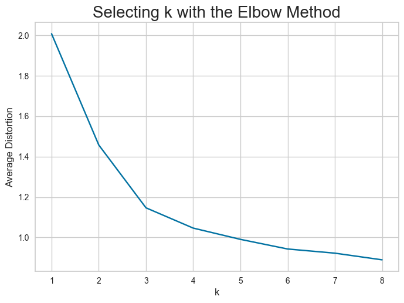

```python
clusters=range(1,9)
meanDistortions=[]

for k in clusters:
    model=KMeans(n_clusters=k)
    model.fit(subset_scaled_df)
    prediction=model.predict(subset_scaled_df)
    distortion=sum(np.min(cdist(subset_scaled_df, model.cluster_centers_, 'euclidean'), axis=1)) / subset_scaled_df.shape[0]

    meanDistortions.append(distortion)

    print('Number of Clusters:', k, '\tAverage Distortion:', distortion)

plt.plot(clusters, meanDistortions, 'bx-')
plt.xlabel('k')
plt.ylabel('Average Distortion')
plt.title('Selecting k with the Elbow Method', fontsize=20)
```

The elbow point is the point on the graph where the rate of decrease in the average distortion (WCSS) starts to slow down, indicating that adding more clusters doesn't provide much additional benefit in reducing the distortion. Therefore, the optimal number of clusters is typically chosen to be the number of clusters at the elbow point.

**Observation** The appropriate value of K from elbow curve above seems to be 3 or 4.

**Let's check Silhoutte Score**

```python
sil_score = []
cluster_list = list(range(2,10))
for n_clusters in cluster_list:
    clusterer = KMeans(n_clusters=n_clusters)
    preds = clusterer.fit_predict((subset_scaled_df))
    #centers = clusterer.cluster_centers_
    score = silhouette_score(subset_scaled_df, preds)
    sil_score.append(score)
    print("For n_clusters = {}, silhouette score is {})".format(n_clusters, score))
```

```
For n_clusters = 2, silhouette score is 0.41842496663215445)
For n_clusters = 3, silhouette score is 0.5157182558881063)
For n_clusters = 4, silhouette score is 0.3556670619372605)
For n_clusters = 5, silhouette score is 0.2726898791817692)
For n_clusters = 6, silhouette score is 0.25583657571102003)
For n_clusters = 7, silhouette score is 0.24809451597323307)
For n_clusters = 8, silhouette score is 0.22689946957787002)
For n_clusters = 9, silhouette score is 0.22614310986863595)
```

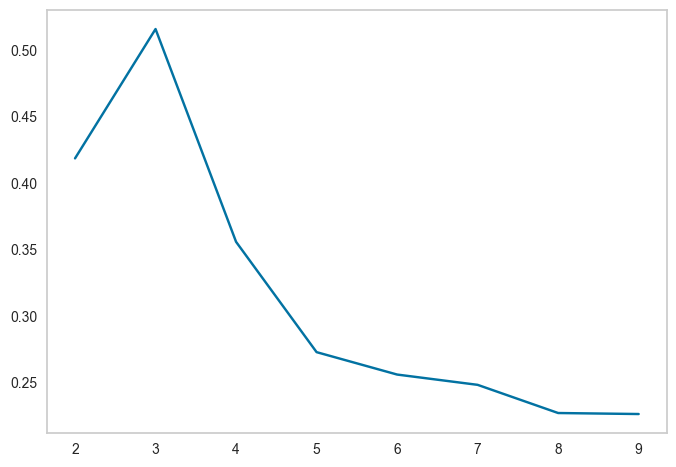

```python
plt.plot(cluster_list,sil_score)
plt.grid()
```

The Silhouette score can be used to evaluate the quality of the clustering results for different values of K (the number of clusters). A higher Silhouette score for a particular value of K indicates that the clustering is more appropriate for the given dat.

From silhoutte score, it seems 3 is good value of K.

The Silhouette scores are calculated for each data point and represent how well the data point fits into its assigned cluster. A higher Silhouette score indicates a better fit.

The visualizer displays a graph where each data point is represented as a horizontal bar, with the length of the bar indicating the Silhouette score for that data point. The bars are grouped by cluster and are sorted in descending order by Silhouette score. The dashed line in the graph represents the average Silhouette score across all data points.

By examining the graph, we can identify the number of clusters that maximizes the average Silhouette score and indicates the best clustering solution for the given data.

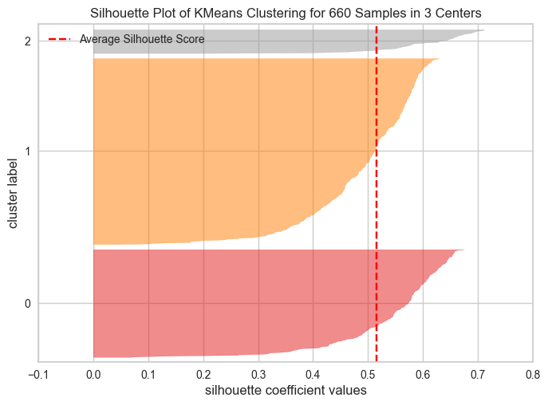

```python
#Finding optimal no. of clusters with silhouette coefficients
visualizer = SilhouetteVisualizer(KMeans(3, random_state = 1))
visualizer.fit(subset_scaled_df)
visualizer.show()

#The purpose of this code is to determine the optimal number of clusters to use in KMeans clustering by visualizing the Silhouette scores.
#The Silhouette score is a measure of how similar an object is to its own cluster (cohesion) compared to other clusters (separation).
```

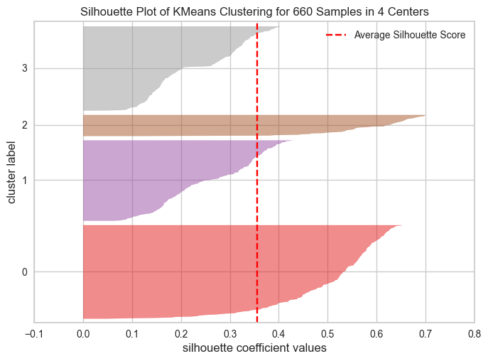

```python
#Finding optimal no. of clusters with silhouette coefficients
visualizer = SilhouetteVisualizer(KMeans(4, random_state = 1))
visualizer.fit(subset_scaled_df)
visualizer.show()
```

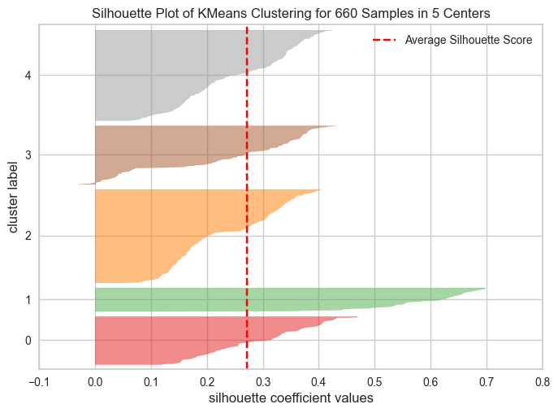

```python
#Finding optimal no. of clusters with silhouette coefficients
visualizer = SilhouetteVisualizer(KMeans(5, random_state = 1))
visualizer.fit(subset_scaled_df)
visualizer.show()
```

**Lets take 3 as appropriate number of clusters as silhoutte score is high and also there is a knick at 3 in eblow curve.**

```python
kmeans = KMeans(n_clusters=3, random_state=0)
kmeans.fit(subset_scaled_df)
```

```
KMeans(n_clusters=3, random_state=0)
```

```python
df['K_means_segments'] = kmeans.labels_
subset_scaled_df['K_means_segments'] = kmeans.labels_
```

```python
cluster_profile = df.groupby('K_means_segments').mean()
```

```python
cluster_profile['count_in_each_segment'] = df.groupby('K_means_segments')['Avg_Credit_Limit'].count().values
```

```python
# lets display cluster profile
cluster_profile.style.highlight_max(color = 'lightgreen', axis = 0)
```

| K_means_segments | Avg_Credit_Limit | Total_Credit_Cards | Total_visits_bank | Total_visits_online | Total_calls_made | count_in_each_segment |
| --- | --- | --- | --- | --- | --- | --- |
| 0 | 33782.383420 | 5.515544 | 3.489637 | 0.981865 | 2.000000 | 386 |
| 1 | 12174.107143 | 2.410714 | 0.933036 | 3.553571 | 6.870536 | 224 |
| 2 | 141040.000000 | 8.740000 | 0.600000 | 10.900000 | 1.080000 | 50 |

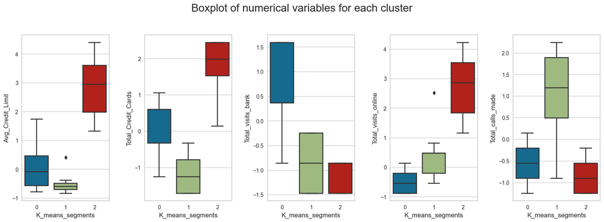

```python
fig, axes = plt.subplots(1, 5,  figsize=(16, 6))
fig.suptitle('Boxplot of numerical variables for each cluster', fontsize=20)
counter = 0
for ii in range(5):
    sns.boxplot(ax=axes[ii],y=subset_scaled_df[all_col[counter]],x=subset_scaled_df['K_means_segments'])
    counter = counter+1

fig.tight_layout(pad=2.0)
```

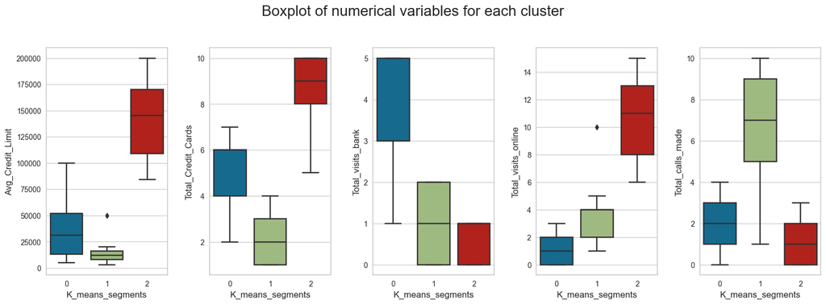

```python
fig, axes = plt.subplots(1, 5,  figsize=(16, 6))
fig.suptitle('Boxplot of numerical variables for each cluster', fontsize=20)
counter = 0
for ii in range(5):
    sns.boxplot(ax=axes[ii],y=df[all_col[counter]],x=df['K_means_segments'])
    counter = counter+1

fig.tight_layout(pad=2.0)
```

#### Insights using K-Means Clustering

As per K-Means, we have three different segments.

#### Using Hierarchical Clustering

We will first evaluate multiple combinations of distance metrics and linkage methods to determine optimal approach to hierarchical clustering. We will use cophenet index to evaluate the quality of hierarchical clustering.

First we will identify distance metrics (euclidean, mahalanobis etc) and linkage methods. We will loop over each combination of distance metric and linkage method, where where hierarchical clustering is applied to the dataset using that combination.

The cophenet function is used to calculate the cophenet correlation coefficient, which measures the correlation between the distance of points in feature space and distance on the dendrogram for the resulting clustering solution. A higher cophenet correlation coefficient indicates a better clustering solution.

The cophenet correlation coefficient is printed for each combination of distance metric and linkage method.

If the highest cophenet correlation coefficient seen so far is surpassed by the current combination of distance metric and linkage method, then the highest cophenet correlation coefficient and corresponding distance metric and linkage method are updated.

```python
# cophenet index is a measure of the correlation between the distance of points in feature space and distance on dendrogram
# closer it is to 1, the better is the clustering
distance_metrics = [ 'euclidean','chebyshev','mahalanobis','cityblock']
linkage_methods = ['single', 'complete', 'average', 'weighted']
high_cophenet_corr = 0
high_dm_lm = [0,0]
for dm in distance_metrics:
    for lm in linkage_methods:
        Z = linkage(subset_scaled_df, metric=dm, method=lm)
        c, coph_dists = cophenet(Z , pdist(subset_scaled_df))
        print('Cophent correlation for distance metrics {} and linkahe method {} is {}'.format(dm,lm,c))
        if high_cophenet_corr < c:
            high_cophenet_corr = c
            high_dm_lm[0] = dm
            high_dm_lm[1] = lm
```

```
Cophent correlation for distance metrics euclidean and linkahe method single is 0.8788676940541079
Cophent correlation for distance metrics euclidean and linkahe method complete is 0.8860521900934342
Cophent correlation for distance metrics euclidean and linkahe method average is 0.9168725782090766
Cophent correlation for distance metrics euclidean and linkahe method weighted is 0.9133393931042242
Cophent correlation for distance metrics chebyshev and linkahe method single is 0.8978014062578786
Cophent correlation for distance metrics chebyshev and linkahe method complete is 0.8623270916886306
Cophent correlation for distance metrics chebyshev and linkahe method average is 0.9160784250471772
Cophent correlation for distance metrics chebyshev and linkahe method weighted is 0.9109044268579872
Cophent correlation for distance metrics mahalanobis and linkahe method single is 0.895995252672423
Cophent correlation for distance metrics mahalanobis and linkahe method complete is 0.6550023123197851
Cophent correlation for distance metrics mahalanobis and linkahe method average is 0.846761889957889
Cophent correlation for distance metrics mahalanobis and linkahe method weighted is 0.8207917162822883
Cophent correlation for distance metrics cityblock and linkahe method single is 0.8406488764445825
Cophent correlation for distance metrics cityblock and linkahe method complete is 0.8890360877047411
Cophent correlation for distance metrics cityblock and linkahe method average is 0.9149250127652871
Cophent correlation for distance metrics cityblock and linkahe method weighted is 0.8901622514742297
```

```python
print('Highest cophenet correlation is {}, which is obtinaed with {} distance metric and {} linkage method'.format(high_cophenet_corr ,high_dm_lm[0],high_dm_lm[1]))
```

```
Highest cophenet correlation is 0.9168725782090766, which is obtinaed with euclidean distance metric and average linkage method
```

**Lets explore 'centroid', 'median','ward' linkage method which requires only Euclidean distance metrics**

```python
linkage_methods = ['single', 'complete', 'average','median','ward', 'weighted']
high_cophenet_corr = 0
high_dm_lm = [0,0]

for lm in linkage_methods:
    Z = linkage(subset_scaled_df, metric='euclidean', method=lm)
    c, coph_dists = cophenet(Z , pdist(subset_scaled_df))
    print('Cophent correlation for distance metrics {} and linkahe method {} is {}'.format('euclidean',lm,c))
    if high_cophenet_corr < c:
        high_cophenet_corr = c
        high_dm_lm[0] = dm
        high_dm_lm[1] = lm
print('*'*110)
print('Highest cophenet correlation is {}, which is obtinaed with {} distance metric and {} linkage method'.format(high_cophenet_corr ,high_dm_lm[0],high_dm_lm[1]))
```

[output not shown]

Visualize the clustering of the dataset using different linkage methods and determine the linkage method that results in the highest cophenetic correlation coefficient, indicating the best clustering solution for the given data. By comparing the cophenetic correlation coefficient across different linkage methods, we can identify the optimal approach for hierarchical clustering on this dataset. The dendrogram plot provides a visual representation of the clustering solution and can be useful in identifying natural clusters within the data.

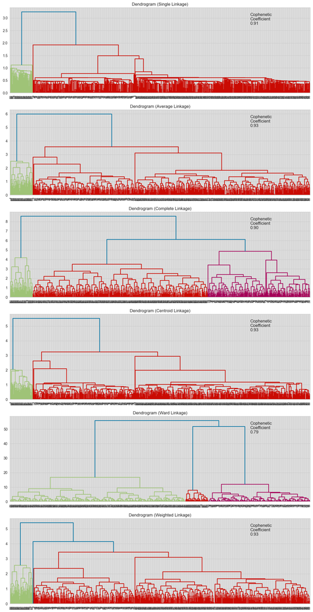

```python
# List of all linkage methods to check
methods = ['single',
           'average',
           'complete',           'centroid',
           'ward',
          'weighted']

# Calculate the pairwise distance form the dataset to be used in the cophenetic correlation calculation
#pw_distance = pdist(credit_scaled)

# Create lists to save results of coph calculation
compare_cols = ['Linkage', 'Cophenetic Coefficient']
compare = []

# Create a subplot image
fig, axs = plt.subplots(len(methods), 1, figsize=(15, 30))

# Enumerate through the list of all methods above
# Get linkage, plot dendrogram, calculate cophenetic coefficient
for i, method in enumerate(methods):

    Z = linkage(subset_scaled_df, metric='euclidean', method=method)

    dendrogram(Z, ax=axs[i]);
    axs[i].set_title(f'Dendrogram ({method.capitalize()} Linkage)')
    coph_corr, coph_dist = cophenet(Z, pdist(subset_scaled_df))
    axs[i].annotate(f'Cophenetic\nCoefficient\n{coph_corr:0.2f}',
                    (0.80, 0.80),
                    xycoords='axes fraction')
    compare.append([method, coph_corr])
```

**Observations** Dendrogram with average linkage method shows distinct and separate cluster

```python
# Create and print dataframe to compare Cophenetic Coefficient for each linkage
df_cc = pd.DataFrame(compare, columns=compare_cols)
df_cc
```

[output not shown]

- Let us see the dndrogram of 'mahalanobis','cityblock' with 'average', 'weighted' linkage method as they gave high cophenetic correlation value

```python
distance_metrics = [ 'mahalanobis','cityblock']
linkage_methods = ['average', 'weighted']
```

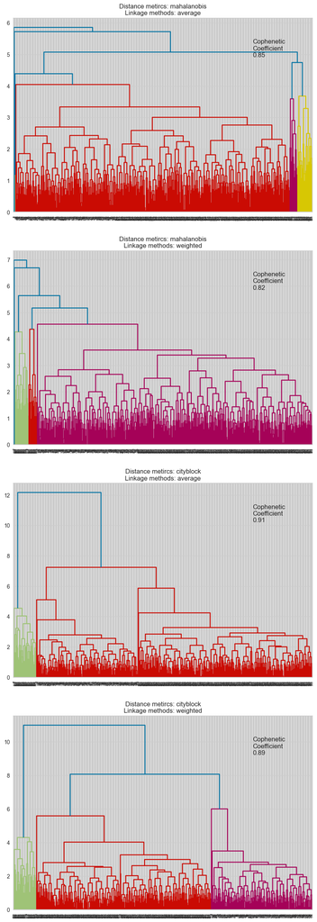

```python
# Create a subplot image
fig, axs = plt.subplots(len(distance_metrics)+len(distance_metrics), 1, figsize=(10, 30))
i=0
for dm in distance_metrics:
    for lm in linkage_methods:
        Z = linkage(subset_scaled_df, metric=dm, method=lm)
        dendrogram(Z,  ax=axs[i]);
        axs[i].set_title('Distance metircs: {}\nLinkage methods: {}'.format(dm,lm))
        coph_corr, coph_dist = cophenet(Z, pdist(subset_scaled_df))
        axs[i].annotate(f'Cophenetic\nCoefficient\n{coph_corr:0.2f}',
                        (0.80, 0.80),
                        xycoords='axes fraction')
        axs[i].set_title('Distance metircs: {}\nLinkage methods: {}'.format(dm,lm))
        i +=1
```

**Observations**

- Out of all the dendrogram we saw, it is clear that dendrogram with ward linkage method gave us separate and distinct clusters
- 3 cluster would be appropriate number of cluster from dendrogram with average linkage method

### Let us create 3 clusters

```python
#Trying with K value as 3
HCmodel = AgglomerativeClustering(n_clusters=3,affinity='euclidean', linkage='ward')
HCmodel.fit(subset_scaled_df)
subset_scaled_df['HC_Clusters'] = HCmodel.labels_
```

```python
df['HC_Clusters'] = HCmodel.labels_
```

```python
cluster_profile = df.groupby('HC_Clusters').mean()
```

```python
cluster_profile['count_in_each_segments'] = df.groupby('HC_Clusters')['Avg_Credit_Limit'].count().values
```

```python
# lets display cluster profile
cluster_profile.style.highlight_max(color = 'lightgreen', axis = 0)
```

| HC_Clusters | Avg_Credit_Limit | Total_Credit_Cards | Total_visits_bank | Total_visits_online | Total_calls_made | K_means_segments | count_in_each_segments |
| --- | --- | --- | --- | --- | --- | --- | --- |
| 0 | 33782.383420 | 5.515544 | 3.489637 | 0.981865 | 2.000000 | 0.000000 | 386 |
| 1 | 12174.107143 | 2.410714 | 0.933036 | 3.553571 | 6.870536 | 1.000000 | 224 |
| 2 | 141040.000000 | 8.740000 | 0.600000 | 10.900000 | 1.080000 | 2.000000 | 50 |

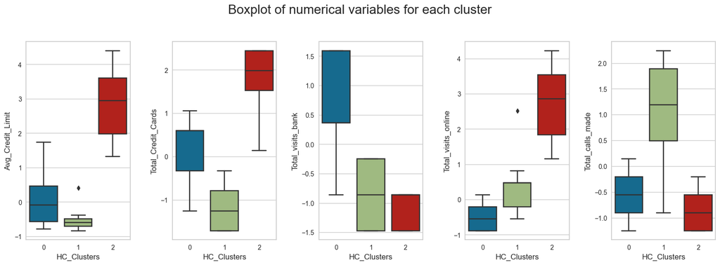

```python
fig, axes = plt.subplots(1, 5,  figsize=(16, 6))
fig.suptitle('Boxplot of numerical variables for each cluster', fontsize=20)
counter = 0
for ii in range(5):
    sns.boxplot(ax=axes[ii],y=subset_scaled_df[all_col[counter]],x=subset_scaled_df['HC_Clusters'])
    counter = counter+1

fig.tight_layout(pad=2.0)
```

**Insights**

Cluster 0 : Bank Visitors

- Average credit limit is low to medium for majority of the customers
- Prefer to often visit bank for transactions
- Rarely visit online for transactions.

Cluster 1 : Phone Call Users

- Low credit limit compared to other clusters.
- Total credit cards is the low amonth all the clusters
- Average online transactions.
- High number of calls to bank

Cluster 2 : Digital Users

- Customers in this cluster has the higest average credit limit among all the clusters
- Customers in this cluster have high number of credit cards among all the clusters
- Often do online transactions

```python
cluster_profile.style.highlight_max(color = 'lightgreen', axis = 0)
```

| HC_Clusters | Avg_Credit_Limit | Total_Credit_Cards | Total_visits_bank | Total_visits_online | Total_calls_made | K_means_segments | count_in_each_segments |
| --- | --- | --- | --- | --- | --- | --- | --- |
| 0 | 33782.383420 | 5.515544 | 3.489637 | 0.981865 | 2.000000 | 0.000000 | 386 |
| 1 | 12174.107143 | 2.410714 | 0.933036 | 3.553571 | 6.870536 | 1.000000 | 224 |
| 2 | 141040.000000 | 8.740000 | 0.600000 | 10.900000 | 1.080000 | 2.000000 | 50 |

### Business Recommendations

- Cluster 0 Customers - Often visit bank for transactions. Banks should promote online usage among these customers.
- Cluster 1 Customers - They have low credit limit and also have less number of credit cards. Bank should provide higher credit limit to these customers. Also improve phone customer services.